# Project 2: Investigate the European Soccer Database

### Research Question 3)

**Who runs North London?**: Which team in North London has achieved the most wins?

```python
# Create a subset of EPL teams only, count the wins over the time period and produce a top 6 ranking
# I expect Arsenal and Tottenham Hotspur to be in the top 6 teams over the reference period

epl = match_clean.query('league_name == "England Premier League"')
top_6 = epl.groupby('outcome')['outcome'].count().sort_values(ascending=False)[1:7]
```

```python
top_6
```

```
outcome
Manchester United    192
Chelsea              176
Manchester City      175
Arsenal              170
Tottenham Hotspur    151
Liverpool            150
Name: outcome, dtype: int64
```

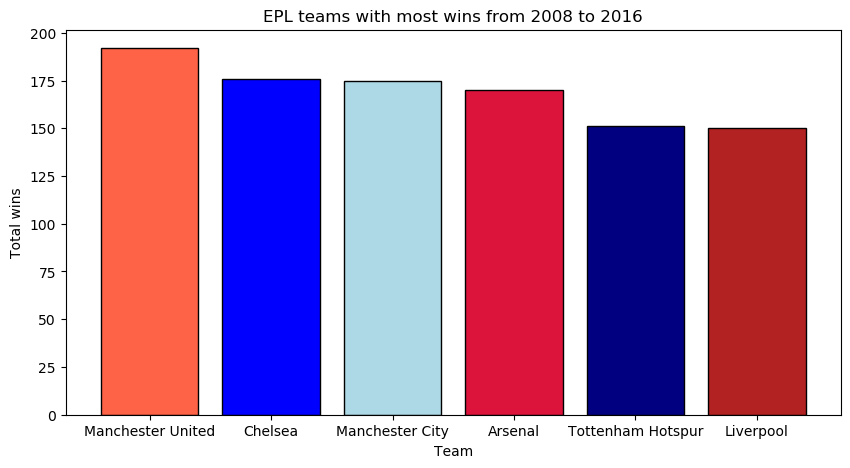

```python
# Plot the results, and add the jersey colour to the graph :D

plt.figure(figsize=(10,5))
plt.bar(top_6.index,top_6,color=['tomato', 'blue', 'lightblue', 'crimson', 'navy', 'firebrick'],edgecolor='black')
plt.title('EPL teams with most wins from 2008 to 2016')
plt.xlabel('Team')
plt.ylabel('Total wins');
```

Here, we can see that Arsenal (170) has more wins over Tottenham Hotspur (151) across the reference period, indicating that Arsenal are the more dominant team in North London.

It is interesting to note that Arsenal have a similar number of wins as Chelsea and Manchester City who both have high-profile wealthy ownership which invest significantly in the purchase of big-name players. Arsenal have notoriously been low "spenders" during the reference period, so the fact that Arsenal have maintained a consistent number of wins is admirable (note, this is from an Arsenal fan!).

To extend this study further, it would be interesting to link in transfer spend data and to look at trends across time of both transfer expenditure and team performance.

### Research Question 4)

**Speedy gonzales**: Is pace a factor in a player's overall rating?

#### High level analysis

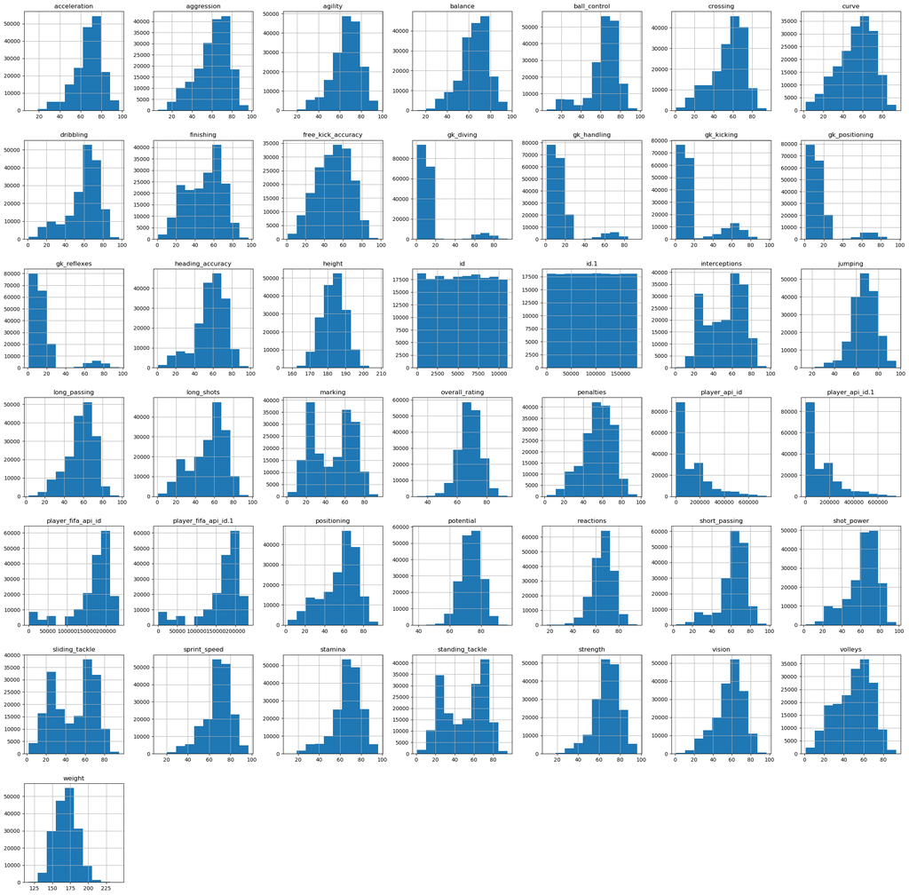

```python
# Produce histograms for player attributes

player_clean.hist(figsize=(30,30));
```

```python
# Produce a correlation matrix for player attributes

corr = player_clean.corr()
corr
```

|  | id | player_api_id | player_fifa_api_id | height | weight | id.1 | player_fifa_api_id.1 | player_api_id.1 | overall_rating | potential | ... | vision | penalties | marking | standing_tackle | sliding_tackle | gk_diving | gk_handling | gk_kicking | gk_positioning | gk_reflexes |
| --- | --- | --- | --- | --- | --- | --- | --- | --- | --- | --- | --- | --- | --- | --- | --- | --- | --- | --- | --- | --- | --- |
| id | 1.000000 | 0.002181 | 0.003607 | 0.009247 | 0.012342 | 0.999989 | 0.003853 | 0.002181 | -0.003743 | 0.000878 | ... | -0.007866 | -0.011783 | -0.010330 | -0.012523 | -0.011132 | 0.014246 | 0.010887 | 0.008686 | 0.013986 | 0.014652 |
| player_api_id | 0.002181 | 1.000000 | 0.556736 | -0.065485 | -0.161037 | 0.002048 | 0.556557 | 1.000000 | -0.328315 | 0.010588 | ... | -0.188087 | -0.162481 | -0.089772 | -0.086706 | -0.073595 | -0.071825 | -0.125345 | -0.229704 | -0.125525 | -0.121947 |
| player_fifa_api_id | 0.003607 | 0.556736 | 1.000000 | -0.040756 | -0.121283 | 0.003499 | 0.999856 | 0.556736 | -0.278784 | -0.021330 | ... | -0.163124 | -0.175265 | -0.075197 | -0.070792 | -0.054939 | -0.093191 | -0.139063 | -0.248324 | -0.141165 | -0.131792 |
| height | 0.009247 | -0.065485 | -0.040756 | 1.000000 | 0.762176 | 0.009334 | -0.040624 | -0.065485 | -0.004651 | -0.035375 | ... | -0.383292 | -0.270864 | 0.045017 | 0.025966 | 0.011284 | 0.315629 | 0.309854 | 0.191084 | 0.309086 | 0.313144 |
| weight | 0.012342 | -0.161037 | -0.121283 | 0.762176 | 1.000000 | 0.012384 | -0.121140 | -0.161037 | 0.063945 | -0.009193 | ... | -0.323229 | -0.194014 | 0.016453 | 0.001163 | -0.014010 | 0.311371 | 0.311752 | 0.211216 | 0.310953 | 0.312210 |
| id.1 | 0.999989 | 0.002048 | 0.003499 | 0.009334 | 0.012384 | 1.000000 | 0.003744 | 0.002048 | -0.003738 | 0.000837 | ... | -0.007928 | -0.011751 | -0.010329 | -0.012515 | -0.011101 | 0.014251 | 0.010911 | 0.008758 | 0.014015 | 0.014671 |
| player_fifa_api_id.1 | 0.003853 | 0.556557 | 0.999856 | -0.040624 | -0.121140 | 0.003744 | 1.000000 | 0.556557 | -0.278703 | -0.021252 | ... | -0.163099 | -0.175255 | -0.075568 | -0.071128 | -0.055218 | -0.092945 | -0.138844 | -0.248222 | -0.140925 | -0.131531 |
| player_api_id.1 | 0.002181 | 1.000000 | 0.556736 | -0.065485 | -0.161037 | 0.002048 | 0.556557 | 1.000000 | -0.328315 | 0.010588 | ... | -0.188087 | -0.162481 | -0.089772 | -0.086706 | -0.073595 | -0.071825 | -0.125345 | -0.229704 | -0.125525 | -0.121947 |
| overall_rating | -0.003743 | -0.328315 | -0.278784 | -0.004651 | 0.063945 | -0.003738 | -0.278703 | -0.328315 | 1.000000 | 0.765435 | ... | 0.431493 | 0.392715 | 0.132185 | 0.163986 | 0.128054 | 0.027675 | 0.006717 | 0.028799 | 0.008029 | 0.007804 |
| potential | 0.000878 | 0.010588 | -0.021330 | -0.035375 | -0.009193 | 0.000837 | -0.021252 | 0.010588 | 0.765435 | 1.000000 | ... | 0.379278 | 0.315207 | 0.054094 | 0.082073 | 0.063284 | -0.012283 | 0.005865 | 0.092299 | 0.004472 | 0.004936 |
| crossing | -0.020163 | -0.113365 | -0.065588 | -0.473698 | -0.411654 | -0.020231 | -0.065631 | -0.113365 | 0.357320 | 0.277284 | ... | 0.693978 | 0.574208 | 0.234886 | 0.285018 | 0.274673 | -0.604567 | -0.595646 | -0.356728 | -0.597742 | -0.601696 |
| finishing | -0.008150 | -0.062312 | -0.029890 | -0.320104 | -0.254560 | -0.008171 | -0.029836 | -0.062312 | 0.330079 | 0.287838 | ... | 0.652376 | 0.726234 | -0.285416 | -0.230453 | -0.262144 | -0.479370 | -0.465135 | -0.292349 | -0.470758 | -0.473302 |
| heading_accuracy | -0.011851 | -0.130282 | -0.103220 | 0.111904 | 0.097846 | -0.011781 | -0.103500 | -0.130282 | 0.313324 | 0.206063 | ... | 0.336472 | 0.431291 | 0.460831 | 0.480054 | 0.441134 | -0.665600 | -0.649145 | -0.402865 | -0.648981 | -0.652494 |
| short_passing | -0.006653 | -0.090237 | -0.065161 | -0.364106 | -0.326018 | -0.006701 | -0.065311 | -0.090237 | 0.458243 | 0.382538 | ... | 0.766401 | 0.612511 | 0.349578 | 0.415427 | 0.380148 | -0.694111 | -0.689874 | -0.422659 | -0.691030 | -0.693260 |
| volleys | -0.006932 | -0.131262 | -0.088748 | -0.335513 | -0.261252 | -0.006916 | -0.088726 | -0.131262 | 0.361739 | 0.301678 | ... | 0.690716 | 0.713116 | -0.170094 | -0.108062 | -0.127810 | -0.508029 | -0.486178 | -0.279492 | -0.490148 | -0.492267 |
| dribbling | -0.014719 | 0.015616 | 0.047592 | -0.490154 | -0.432850 | -0.014784 | 0.047551 | 0.015616 | 0.354191 | 0.339978 | ... | 0.734119 | 0.663420 | 0.004345 | 0.067306 | 0.044988 | -0.654097 | -0.650645 | -0.432452 | -0.653560 | -0.656195 |
| curve | -0.019478 | -0.099430 | -0.052564 | -0.452054 | -0.387934 | -0.019523 | -0.052501 | -0.099430 | 0.357566 | 0.296050 | ... | 0.728198 | 0.649737 | 0.032956 | 0.094466 | 0.080110 | -0.556625 | -0.544940 | -0.333784 | -0.549870 | -0.551574 |
| free_kick_accuracy | -0.008371 | -0.152683 | -0.108860 | -0.383592 | -0.314920 | -0.008396 | -0.108735 | -0.152683 | 0.349800 | 0.262842 | ... | 0.697943 | 0.669018 | 0.072918 | 0.133147 | 0.105894 | -0.498347 | -0.491631 | -0.279713 | -0.494253 | -0.495868 |
| long_passing | -0.008114 | -0.139584 | -0.111083 | -0.297312 | -0.269579 | -0.008137 | -0.111272 | -0.139584 | 0.434525 | 0.343133 | ... | 0.670151 | 0.476750 | 0.441837 | 0.496679 | 0.462544 | -0.464221 | -0.466906 | -0.261361 | -0.468453 | -0.469598 |
| ball_control | -0.013937 | -0.053940 | -0.024812 | -0.419595 | -0.370126 | -0.013976 | -0.024942 | -0.053940 | 0.443991 | 0.401803 | ... | 0.773185 | 0.684410 | 0.188479 | 0.252325 | 0.220588 | -0.741678 | -0.732701 | -0.465803 | -0.735166 | -0.738085 |
| acceleration | -0.008123 | 0.101536 | 0.178265 | -0.522063 | -0.462094 | -0.008212 | 0.178267 | 0.101536 | 0.243998 | 0.338820 | ... | 0.470370 | 0.428884 | -0.034449 | -0.006462 | 0.000558 | -0.481988 | -0.465823 | -0.279128 | -0.468226 | -0.469669 |
| sprint_speed | -0.011803 | 0.094236 | 0.178306 | -0.430250 | -0.385437 | -0.011897 | 0.178343 | 0.094236 | 0.253048 | 0.340698 | ... | 0.435667 | 0.411872 | 0.005501 | 0.033576 | 0.038742 | -0.497846 | -0.479999 | -0.285362 | -0.484227 | -0.485750 |
| agility | -0.000849 | 0.026467 | 0.116158 | -0.618819 | -0.556005 | -0.000947 | 0.116309 | 0.026467 | 0.239963 | 0.293714 | ... | 0.559152 | 0.442737 | -0.126362 | -0.091032 | -0.080848 | -0.388833 | -0.380188 | -0.243554 | -0.382839 | -0.383367 |
| reactions | -0.005750 | -0.312538 | -0.233568 | -0.082576 | -0.019009 | -0.005740 | -0.233465 | -0.312538 | 0.771856 | 0.580991 | ... | 0.452559 | 0.390045 | 0.123173 | 0.159255 | 0.137098 | -0.073940 | -0.079753 | -0.033067 | -0.078091 | -0.078300 |
| balance | -0.009859 | 0.021300 | 0.008198 | -0.672173 | -0.555836 | -0.009909 | 0.008350 | 0.021300 | 0.160211 | 0.202232 | ... | 0.507510 | 0.391050 | 0.036002 | 0.063704 | 0.075284 | -0.386654 | -0.362838 | -0.184204 | -0.364395 | -0.366849 |
| shot_power | -0.010374 | -0.126514 | -0.079996 | -0.250186 | -0.170661 | -0.010371 | -0.080175 | -0.126514 | 0.428053 | 0.325459 | ... | 0.647262 | 0.680887 | 0.094068 | 0.155941 | 0.117569 | -0.584551 | -0.589048 | -0.398712 | -0.591626 | -0.593827 |
| jumping | -0.004316 | -0.141646 | -0.073014 | -0.003158 | 0.042218 | -0.004279 | -0.073277 | -0.141646 | 0.258978 | 0.174532 | ... | 0.017372 | 0.058097 | 0.194289 | 0.188607 | 0.199657 | -0.038265 | -0.037035 | -0.014910 | -0.035719 | -0.034010 |
| stamina | -0.010458 | -0.109958 | 0.015467 | -0.236377 | -0.212975 | -0.010506 | 0.015277 | -0.109958 | 0.325606 | 0.259432 | ... | 0.506252 | 0.399233 | 0.416995 | 0.459434 | 0.437001 | -0.554568 | -0.543677 | -0.320408 | -0.542760 | -0.547975 |
| strength | -0.009025 | -0.234866 | -0.178140 | 0.519012 | 0.563952 | -0.008954 | -0.178351 | -0.234866 | 0.315684 | 0.122392 | ... | -0.039883 | 0.056923 | 0.356111 | 0.365857 | 0.324646 | -0.070762 | -0.083506 | -0.061410 | -0.084202 | -0.083624 |
| long_shots | -0.010358 | -0.119638 | -0.068653 | -0.361112 | -0.288412 | -0.010382 | -0.068652 | -0.119638 | 0.392668 | 0.313059 | ... | 0.730112 | 0.714596 | -0.011926 | 0.054655 | 0.022683 | -0.545446 | -0.538702 | -0.337826 | -0.542884 | -0.544979 |
| aggression | -0.018067 | -0.212509 | -0.169974 | 0.028850 | 0.067334 | -0.018034 | -0.170147 | -0.212509 | 0.322782 | 0.162137 | ... | 0.276333 | 0.218452 | 0.652986 | 0.682715 | 0.654777 | -0.433406 | -0.431515 | -0.270683 | -0.430153 | -0.432776 |
| interceptions | -0.008485 | -0.185482 | -0.168939 | 0.001858 | -0.007965 | -0.008480 | -0.169307 | -0.185482 | 0.249094 | 0.163292 | ... | 0.233281 | 0.077169 | 0.835412 | 0.848326 | 0.825515 | -0.375410 | -0.336190 | -0.090819 | -0.330958 | -0.335409 |
| positioning | -0.015610 | -0.105157 | -0.078818 | -0.374485 | -0.305190 | -0.015643 | -0.078862 | -0.105157 | 0.368978 | 0.326898 | ... | 0.740857 | 0.753908 | -0.075977 | -0.015256 | -0.042476 | -0.546791 | -0.505852 | -0.233736 | -0.511490 | -0.516008 |
| vision | -0.007866 | -0.188087 | -0.163124 | -0.383292 | -0.323229 | -0.007928 | -0.163099 | -0.188087 | 0.431493 | 0.379278 | ... | 1.000000 | 0.665802 | 0.080042 | 0.144749 | 0.118656 | -0.502582 | -0.461778 | -0.201738 | -0.465109 | -0.470499 |
| penalties | -0.011783 | -0.162481 | -0.175265 | -0.270864 | -0.194014 | -0.011751 | -0.175255 | -0.162481 | 0.392715 | 0.315207 | ... | 0.665802 | 1.000000 | -0.043649 | 0.005405 | -0.030404 | -0.470286 | -0.435311 | -0.189194 | -0.439610 | -0.443635 |
| marking | -0.010330 | -0.089772 | -0.075197 | 0.045017 | 0.016453 | -0.010329 | -0.075568 | -0.089772 | 0.132185 | 0.054094 | ... | 0.080042 | -0.043649 | 1.000000 | 0.950370 | 0.937716 | -0.382682 | -0.376709 | -0.202480 | -0.370921 | -0.373047 |
| standing_tackle | -0.012523 | -0.086706 | -0.070792 | 0.025966 | 0.001163 | -0.012515 | -0.071128 | -0.086706 | 0.163986 | 0.082073 | ... | 0.144749 | 0.005405 | 0.950370 | 1.000000 | 0.953264 | -0.418985 | -0.418084 | -0.244711 | -0.412529 | -0.415528 |
| sliding_tackle | -0.011132 | -0.073595 | -0.054939 | 0.011284 | -0.014010 | -0.011101 | -0.055218 | -0.073595 | 0.128054 | 0.063284 | ... | 0.118656 | -0.030404 | 0.937716 | 0.953264 | 1.000000 | -0.399978 | -0.392203 | -0.212487 | -0.386481 | -0.389127 |
| gk_diving | 0.014246 | -0.071825 | -0.093191 | 0.315629 | 0.311371 | 0.014251 | -0.092945 | -0.071825 | 0.027675 | -0.012283 | ... | -0.502582 | -0.470286 | -0.382682 | -0.418985 | -0.399978 | 1.000000 | 0.926869 | 0.583455 | 0.928024 | 0.936807 |
| gk_handling | 0.010887 | -0.125345 | -0.139063 | 0.309854 | 0.311752 | 0.010911 | -0.138844 | -0.125345 | 0.006717 | 0.005865 | ... | -0.461778 | -0.435311 | -0.376709 | -0.418084 | -0.392203 | 0.926869 | 1.000000 | 0.746524 | 0.965876 | 0.966029 |
| gk_kicking | 0.008686 | -0.229704 | -0.248324 | 0.191084 | 0.211216 | 0.008758 | -0.248222 | -0.229704 | 0.028799 | 0.092299 | ... | -0.201738 | -0.189194 | -0.202480 | -0.244711 | -0.212487 | 0.583455 | 0.746524 | 1.000000 | 0.745670 | 0.739146 |
| gk_positioning | 0.013986 | -0.125525 | -0.141165 | 0.309086 | 0.310953 | 0.014015 | -0.140925 | -0.125525 | 0.008029 | 0.004472 | ... | -0.465109 | -0.439610 | -0.370921 | -0.412529 | -0.386481 | 0.928024 | 0.965876 | 0.745670 | 1.000000 | 0.966407 |
| gk_reflexes | 0.014652 | -0.121947 | -0.131792 | 0.313144 | 0.312210 | 0.014671 | -0.131531 | -0.121947 | 0.007804 | 0.004936 | ... | -0.470499 | -0.443635 | -0.373047 | -0.415528 | -0.389127 | 0.936807 | 0.966029 | 0.739146 | 0.966407 | 1.000000 |

43 rows × 43 columns

```python
# Produce descriptive statistics for player attributes

player_clean.describe().transpose()
```

|  | count | mean | std | min | 25% | 50% | 75% | max |
| --- | --- | --- | --- | --- | --- | --- | --- | --- |
| id | 180354.0 | 5520.609207 | 3190.378836 | 1.00 | 2758.00 | 5533.00 | 8253.00 | 11075.00 |
| player_api_id | 180354.0 | 137653.145514 | 137599.735284 | 2625.00 | 35451.00 | 80291.00 | 192841.00 | 750584.00 |
| player_fifa_api_id | 180354.0 | 166805.312530 | 52825.971635 | 2.00 | 156593.00 | 183774.00 | 200130.00 | 234141.00 |
| height | 180354.0 | 181.877895 | 6.398588 | 157.48 | 177.80 | 182.88 | 185.42 | 208.28 |
| weight | 180354.0 | 168.774593 | 15.098388 | 117.00 | 159.00 | 168.00 | 179.00 | 243.00 |
| id.1 | 180354.0 | 91995.886274 | 53092.657914 | 1.00 | 46074.25 | 92003.50 | 137935.75 | 183978.00 |
| player_fifa_api_id.1 | 180354.0 | 166822.125803 | 52821.443279 | 2.00 | 156616.00 | 183792.00 | 200138.00 | 234141.00 |
| player_api_id.1 | 180354.0 | 137653.145514 | 137599.735284 | 2625.00 | 35451.00 | 80291.00 | 192841.00 | 750584.00 |
| overall_rating | 180354.0 | 68.635317 | 7.027950 | 33.00 | 64.00 | 69.00 | 73.00 | 94.00 |
| potential | 180354.0 | 73.479457 | 6.581963 | 39.00 | 69.00 | 74.00 | 78.00 | 97.00 |
| crossing | 180354.0 | 55.142071 | 17.247231 | 1.00 | 45.00 | 59.00 | 68.00 | 95.00 |
| finishing | 180354.0 | 49.962136 | 19.041760 | 1.00 | 34.00 | 53.00 | 65.00 | 97.00 |
| heading_accuracy | 180354.0 | 57.263476 | 16.478716 | 1.00 | 49.00 | 60.00 | 68.00 | 98.00 |
| short_passing | 180354.0 | 62.486726 | 14.172493 | 3.00 | 57.00 | 65.00 | 72.00 | 97.00 |
| volleys | 180354.0 | 49.488927 | 18.252319 | 1.00 | 35.00 | 52.00 | 64.00 | 93.00 |
| dribbling | 180354.0 | 59.265755 | 17.741351 | 1.00 | 52.00 | 64.00 | 72.00 | 97.00 |
| curve | 180354.0 | 53.001408 | 18.245476 | 2.00 | 41.00 | 56.00 | 67.00 | 94.00 |
| free_kick_accuracy | 180354.0 | 49.392783 | 17.820262 | 1.00 | 36.00 | 50.00 | 63.00 | 97.00 |
| long_passing | 180354.0 | 57.084578 | 14.412035 | 3.00 | 49.00 | 59.00 | 67.00 | 97.00 |
| ball_control | 180354.0 | 63.453846 | 15.187692 | 5.00 | 59.00 | 67.00 | 73.00 | 97.00 |
| acceleration | 180354.0 | 67.709405 | 13.011580 | 10.00 | 61.00 | 69.00 | 77.00 | 97.00 |
| sprint_speed | 180354.0 | 68.101628 | 12.585984 | 12.00 | 62.00 | 69.00 | 77.00 | 97.00 |
| agility | 180354.0 | 65.995082 | 12.963670 | 11.00 | 58.00 | 68.00 | 75.00 | 96.00 |
| reactions | 180354.0 | 66.148297 | 9.145011 | 17.00 | 61.00 | 67.00 | 72.00 | 96.00 |
| balance | 180354.0 | 65.190082 | 13.076192 | 12.00 | 58.00 | 67.00 | 74.00 | 96.00 |
| shot_power | 180354.0 | 61.866474 | 16.129537 | 2.00 | 54.00 | 66.00 | 73.00 | 97.00 |
| jumping | 180354.0 | 66.977333 | 11.017828 | 14.00 | 60.00 | 68.00 | 74.00 | 96.00 |
| stamina | 180354.0 | 67.053401 | 13.200669 | 10.00 | 61.00 | 69.00 | 76.00 | 96.00 |
| strength | 180354.0 | 67.432477 | 12.085131 | 10.00 | 60.00 | 69.00 | 76.00 | 96.00 |
| long_shots | 180354.0 | 53.387560 | 18.370204 | 1.00 | 41.00 | 58.00 | 67.00 | 96.00 |
| aggression | 180354.0 | 60.946217 | 16.101618 | 6.00 | 51.00 | 64.00 | 73.00 | 97.00 |
| interceptions | 180354.0 | 51.897374 | 19.483338 | 1.00 | 34.00 | 56.00 | 68.00 | 96.00 |
| positioning | 180354.0 | 55.730730 | 18.458218 | 2.00 | 45.00 | 60.00 | 69.00 | 95.00 |
| vision | 180354.0 | 57.868176 | 15.152408 | 1.00 | 49.00 | 60.00 | 69.00 | 97.00 |
| penalties | 180354.0 | 54.933448 | 15.556645 | 2.00 | 45.00 | 57.00 | 67.00 | 96.00 |
| marking | 180354.0 | 46.757433 | 21.226730 | 1.00 | 25.00 | 50.00 | 66.00 | 94.00 |
| standing_tackle | 180354.0 | 50.354065 | 21.496289 | 1.00 | 29.00 | 56.00 | 69.00 | 95.00 |
| sliding_tackle | 180354.0 | 48.029342 | 21.592830 | 2.00 | 25.00 | 53.00 | 67.00 | 95.00 |
| gk_diving | 180354.0 | 14.696685 | 16.841454 | 1.00 | 7.00 | 10.00 | 13.00 | 94.00 |
| gk_handling | 180354.0 | 15.947786 | 15.841297 | 1.00 | 8.00 | 11.00 | 15.00 | 93.00 |
| gk_kicking | 180354.0 | 20.526304 | 21.143898 | 1.00 | 8.00 | 12.00 | 15.00 | 97.00 |
| gk_positioning | 180354.0 | 16.015043 | 16.070772 | 1.00 | 8.00 | 11.00 | 15.00 | 96.00 |
| gk_reflexes | 180354.0 | 16.325310 | 17.185450 | 1.00 | 8.00 | 11.00 | 15.00 | 96.00 |

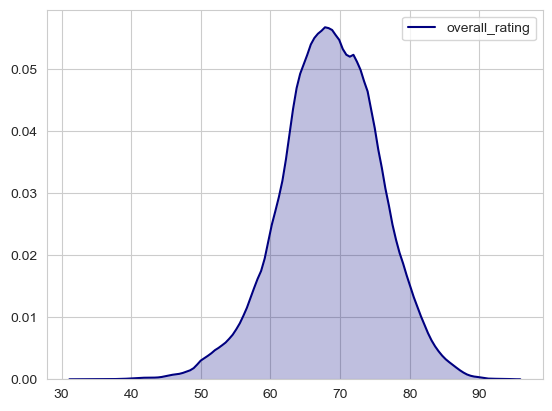

```python
# Plot the distribution of overall player rating

sns.set_style("whitegrid")
sns.kdeplot(player.overall_rating, shade=True, color="navy");
```

```python
# Produce descriptive statistics for overall rating only

player_clean.overall_rating.describe()
```

```
count    180354.000000
mean         68.635317
std           7.027950
min          33.000000
25%          64.000000
50%          69.000000
75%          73.000000
max          94.000000
Name: overall_rating, dtype: float64
```

#### Analysis of pace and overall rating

There are two key metrics that could be used as a proxy for pace. These are 'acceleration' and 'sprint_speed'. First I would like to check whether they are highly correlated (as would be my expectation), and then I will use one to compare with 'overall_rating'.

```python
# Correlation between acceleration and sprint_speed

player_clean['acceleration'].corr(player['sprint_speed'])
```

```
0.9050435815597864
```

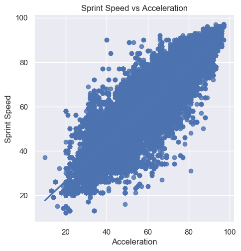

```python
# Plot scatter plot results

sns.set()
sns.lmplot(x='acceleration',y='sprint_speed',data=player_clean)
plt.title('Sprint Speed vs Acceleration')
plt.xlabel('Acceleration')
plt.ylabel('Sprint Speed');
```

There is a high correlation between 'sprint_speed' and 'acceleration'. I will choose to use 'sprint_speed' for the analysis with 'overall_rating'.

```python
# Correlation between overall_rating and sprint_speed

player_clean['overall_rating'].corr(player['sprint_speed'])
```

```
0.25304806290254583
```

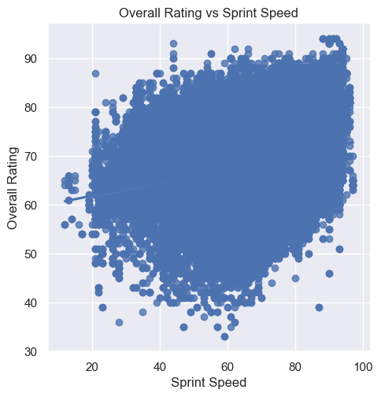

```python
# Plot scatter plot results

sns.set()
sns.lmplot(x='sprint_speed',y='overall_rating',data=player_clean)
plt.title('Overall Rating vs Sprint Speed')
plt.xlabel('Sprint Speed')
plt.ylabel('Overall Rating');
```

There appears to be a weak positive correlation between 'sprint_speed' and 'overall_rating'. I suspect that there may be some value in extending this study to differentiate between defensive and offensive players, as my hypothesis would be such that there would be a stronger correlation between 'sprint_speed' and 'overall_rating' for offensive players where running at speed is a valuable attribute, than for defensive players.

## Conclusions

1. **Home fortress?**: Does a home advantage exist, and if so, which league has the strongest such advantage?

> A home advantage does exist across all leagues. On a goals per match basis, the advantage is strongest in Spain LIGA BBVA (58.95% of goals are scored by the home team).
1. **Who are the goal machines and goal leakers?**: What are the best and worst performing home and away teams?
> - Lowest home scorer: SpVgg Greuther Fürth (10 home goals)
> - Highest home scorer: Real Madrid (505 home goals)
> - Lowest away scorer: FC Metz (5 away goals)
> - Highest away scorer: FC Barcelona (354 away goals)

> Note, the lowest scoring teams should be taken with a grain of salt as these may be newly promoted teams who have not been in the top league for an extended period of time.
1. **Who runs North London?**: Which team in North London has achieved the most wins?

> As an Arsenal fan, it gives me great pleasure to report that Arsenal is the most dominant team in North London with 170 wins to Tottenham Hotspur's 151 wins.
1. **Speedy gonzales**: Is pace a factor in a player's overall rating?

> Whilst there is a slightly positive correlation between sprint speed and overall rating, it does not appear to be very strong.

> To extend this study further, it would be useful to segment between defensive and offensive players, as my hypothesis would be that offensive players with pace may have a higher overall rating, whilst sprint speed may not be as relevant to defensive players.